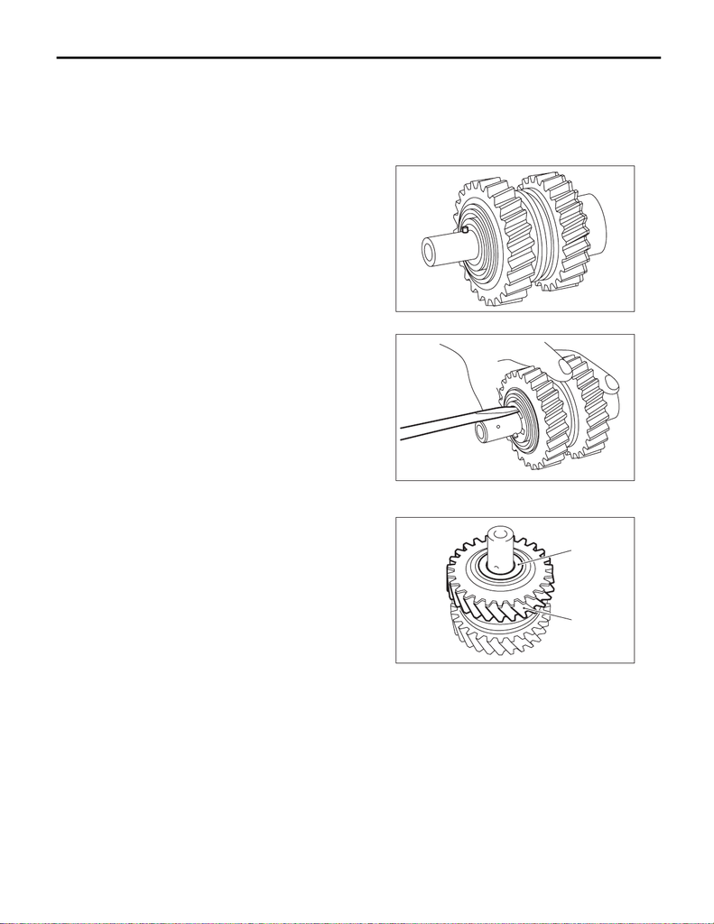

6MT(TY85)-87

Reverse Idler Gear Assembly

MANUAL TRANSMISSION AND DIFFERENTIAL

21.Reverse Idler Gear Assembly

A: REMOVAL

1) Remove the manual transmission assembly

from the vehicle. <Ref. to 6MT(TY85)-31, REMOV-

AL, Manual Transmission Assembly.>

2) Prepare the transmission for overhaul. <Ref. to

6MT(TY85)-38, Preparation for Overhaul.>

3) Remove the neutral position switch, back-up

light switch and harness. <Ref. to 6MT(TY85)-41,

REMOVAL, Neutral Position Switch.> <Ref. to

6MT(TY85)-40, REMOVAL, Back-up Light

Switch.>

4) Remove the extension case. <Ref. to

6MT(TY85)-42, REMOVAL, Extension Case.>

5) Remove the transfer driven gear. <Ref. to

6MT(TY85)-54, REMOVAL, Transfer Driven

Gear.>

6) Remove the center differential. <Ref. to

6MT(TY85)-56, REMOVAL, Center Differential.>

7) Remove the transmission case. <Ref. to

6MT(TY85)-57, REMOVAL, Transmission Case.>

8) Remove the reverse idler gear assembly. <Ref.

to 6MT(TY85)-63, REMOVAL, Main Shaft Assem-

bly.>

B: INSTALLATION

1) Select the reverse fork rod. <Ref. to 6MT(TY85)-

110, ADJUSTMENT, Shifter Fork and Rod.>

2) Install the reverse idler gear assembly. <Ref. to

6MT(TY85)-64, INSTALLATION, Main Shaft As-

sembly.>

3) Install the transmission case. <Ref. to

6MT(TY85)-59, INSTALLATION, Transmission

Case.>

4) Install the center differential. <Ref. to

6MT(TY85)-56, INSTALLATION, Center Differen-

tial.>

5) Install the transfer driven gear. <Ref. to

6MT(TY85)-54, INSTALLATION, Transfer Driven

Gear.>

6) Install the extension case. <Ref. to 6MT(TY85)-

42, INSTALLATION, Extension Case.>

7) Install the neutral position switch, back-up light

switch and harness. <Ref. to 6MT(TY85)-41, IN-

STALLATION, Neutral Position Switch.> <Ref. to

6MT(TY85)-40, INSTALLATION, Back-up Light

Switch.>

8) Install the manual transmission assembly to the

vehicle. <Ref. to 6MT(TY85)-33, INSTALLATION,

Manual Transmission Assembly.>

C: DISASSEMBLY

NOTE:

Sleeves and reverse gears meet at a specified po-

sition. Before disassembly, mark the meeting posi-

tion of the sleeve and hub.

1) Remove the straight pin.

2) Remove the snap ring and washer.

3) Remove the counter high & low washer and re-

verse idler gear.

(A) Counter high and low washer

(B) Reverse idler gear

MT-00617

MT-00618

MT-00619

(B)

(A)

15WRX_STI_US_EN.book 87 ページ ２０１５年２月１３日 金曜日 午前１１時２０分

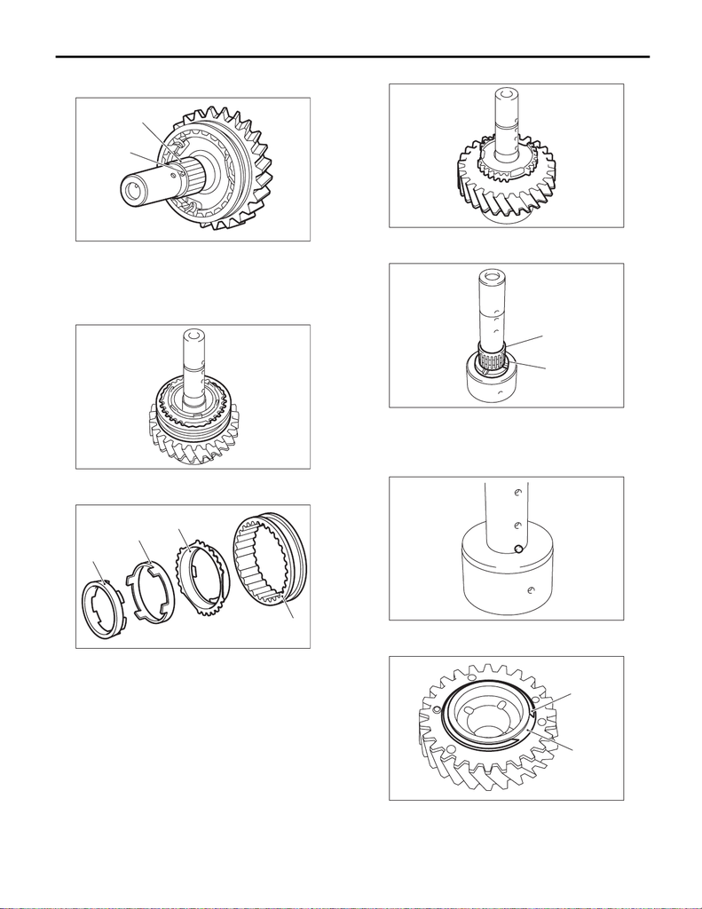

6MT(TY85)-88

Reverse Idler Gear Assembly

MANUAL TRANSMISSION AND DIFFERENTIAL

4) Remove the knock pin and reverse idler gear

needle bearing.

5) Remove the collar.

6) Remove the reverse sleeve.

7) Remove the outer baulk ring, reverse synchro

cone and inner baulk ring from the reverse sleeve.

8) Remove reverse idler gear No. 2.

9) Remove the counter high & low washer and nee-

dle bearing.

10) Remove the knock pin.

11) Remove the snap ring and friction plate from

reverse gear.

(A) Knock pin

(B) Reverse idler gear needle bearing

(A) Reverse sleeve

(B) Outer baulk ring

(C) Reverse synchro cone

(D) Inner baulk ring

MT-00620

(A)

(B)

MT-00622

MT-01507

(A)

(B)

(C)

(D)

(A) Needle bearing

(B) Counter high and low washer

(A) Snap ring

(B) Friction plate

MT-00624

MT-00625

(A)

(B)

MT-00626

MT-00627

(B)

(A)

15WRX_STI_US_EN.book 88 ページ ２０１５年２月１３日 金曜日 午前１１時２０分

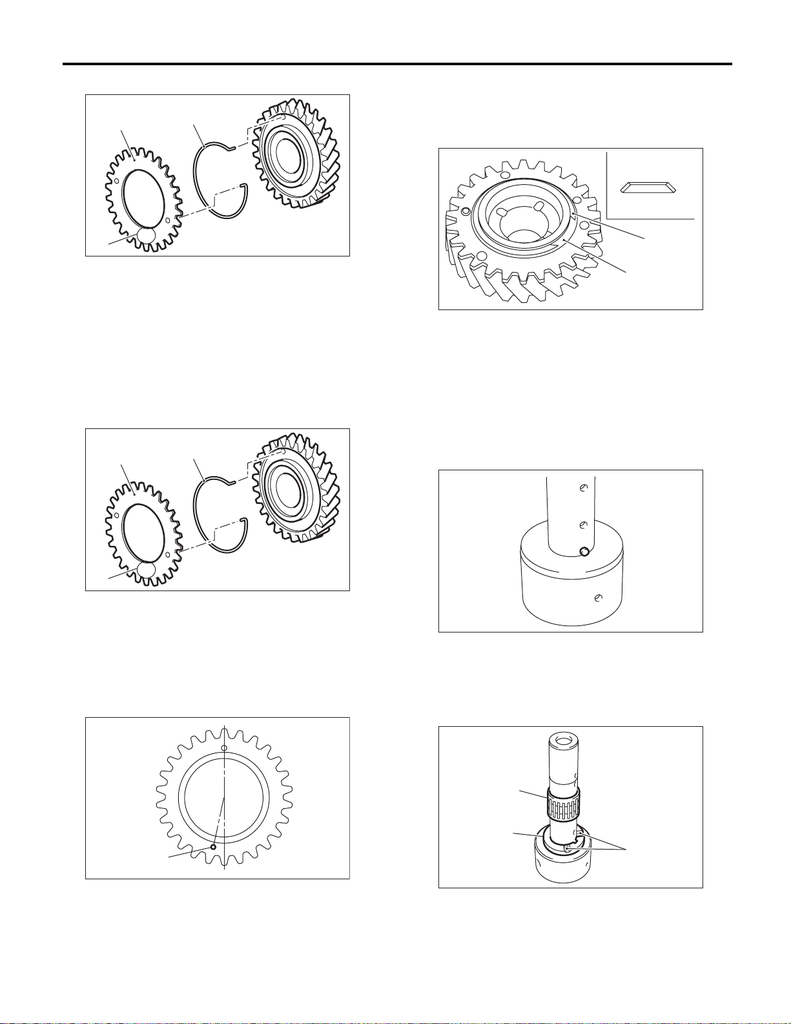

6MT(TY85)-89

Reverse Idler Gear Assembly

MANUAL TRANSMISSION AND DIFFERENTIAL

12) Remove the reverse idler sub gear and spring.

D: ASSEMBLY

1) Attach the reverse idler sub gear and spring.

NOTE:

• Point the stamp (marking A) towards the outside,

and install the reverse idler sub gear.

• While paying attention to the direction of the re-

verse idler sub gear attachment hole, attach the

spring and reverse idler sub gear.

2) Install the friction plate and snap ring.

NOTE:

Confirm that the friction plate is installed in the

proper direction.

3) Apply adequate transmission gear oil to the

shaft, needle bearing and reverse drive gear inner

surface.

4) Install the knock pin.

5) Install the counter high & low washer and needle

bearing.

NOTE:

Point the groove towards the reverse idler gear,

and attach the washer.

(A) Reverse idler sub gear

(B) Spring

(C) Stamp (marking A)

(A) Reverse idler sub gear

(B) Spring

(C) Stamp (marking A)

(A) Attachment hole

MT-03143

(B)

(A)

(C)

A

MT-03143

(B)

(A)

(C)

A

MT-00629

(A)

A

(A) Friction plate

(B) Snap ring

(C) Snap ring side

(D) Reverse idler sub gear side

(A) Groove

(B) Counter high and low washer

(C) Needle bearing

MT-00630

(C)

(D)

(A)

(B)

MT-00626

MT-00631

(C)

(B)

(A)

15WRX_STI_US_EN.book 89 ページ ２０１５年２月１３日 金曜日 午前１１時２０分

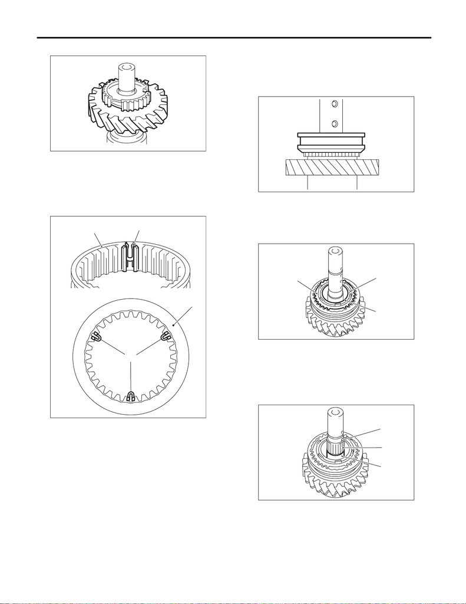

6MT(TY85)-90

Reverse Idler Gear Assembly

MANUAL TRANSMISSION AND DIFFERENTIAL

6) Install the reverse idler gear No. 2.

7) Attach the shifting insert to the appropriate loca-

tion of the reverse sleeve.

NOTE:

• The location angle of each shifting insert is 120°.

• Refer to the following figure to install the shifting

insert.

8) Install the reverse coupling sleeve to the reverse

idler gear No. 2.

NOTE:

Confirm that the reverse coupling sleeve is in-

stalled in the proper direction.

9) Apply adequate transmission gear oil to the col-

lar, needle bearing and reverse drive gear inner

surface.

10) Install the reverse outer baulk ring, reverse

synchro cone and reverse inner baulk ring.

11) Install the collar and needle bearing, then the

knock pin.

(A) Reverse sleeve

(B) Shifting insert

MT-00632

(B)

(A)

(B)

(A)

MT-00633

(A) Reverse outer baulk ring

(B) Reverse synchro cone

(C) Reverse inner baulk ring

(A) Collar

(B) Needle bearing

(C) Knock pin

MT-00634

MT-00635

(A)

(B)

(C)

MT-00636

(C)

(B)

(A)

15WRX_STI_US_EN.book 90 ページ ２０１５年２月１３日 金曜日 午前１１時２０分

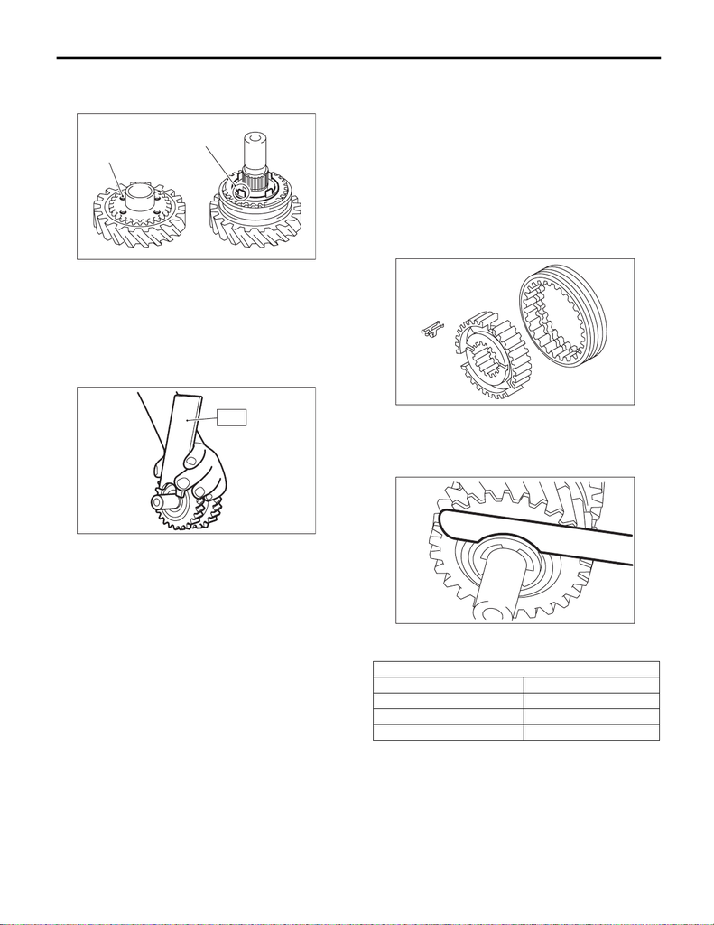

6MT(TY85)-91

Reverse Idler Gear Assembly

MANUAL TRANSMISSION AND DIFFERENTIAL

12) Match the protrusion of the reverse synchro

cone to the hole on the reverse idler gear, and in-

stall the reverse idler gear.

13) Point the groove towards the reverse idler gear,

and attach the counter high & low washer and the

washer.

14) Using the ST, install the snap ring.

ST 18672AA000 GUIDE CLIP

15) Inspect and adjust the clearance between the

snap ring and the washer. <Ref. to 6MT(TY85)-91,

INSPECTION, Reverse Idler Gear Assembly.>

16) Install a new straight pin.

E: INSPECTION

Disassembled parts should be washed with clean-

ing solvent first, then inspected carefully.

1) Bearing

Replace the bearings in the following cases.

• Wear, rusting or damage of the bearings

• The bearing does not rotate smoothly or an ab-

normal noise is emitted when turning.

• The bearing has other defects.

2) Bushing (each gear)

Replace the bushing in following cases.

• The sliding surface is damaged or abnormally

worn.

3) Gear

Replace gears in the following cases.

• The gear teeth surface is damaged or excessive-

ly worn.

• The contact area of the baulk ring is damaged.

• The inner face of the gear is worn.

4) Baulk ring, synchro cone

Replace the baulk ring and synchro cone in the fol-

lowing cases.

• Wear, rusting or damage of the baulk ring

5) Shifting insert

Replace the shifting insert if deformed, excessively

worn or defective in any way.

6) Check clearance between the snap ring and

washer.

Clearance specification:

0.1 — 0.3 mm (0.0039 — 0.0118 in)

If the clearance is out of the specification, select a

snap ring from the following table and replace it.

After replacing the snap ring, inspect the clearance.

(A) Protrusion on the reverse synchro cone

(B) Hole of the reverse idler gear

MT-01508

(A)

(B)

MT-00638

ST

Snap ring

Part No. Thickness mm (in)

031319000 1.50 (0.059)

805019030 1.60 (0.062)

805019010 1.72 (0.068)

MT-00581

MT-00639

15WRX_STI_US_EN.book 91 ページ ２０１５年２月１３日 金曜日 午前１１時２０分